# Reglas de asociación Black Friday

```r
#install.packages("arulesViz")
library(arules)
library(arulesViz)
library(tidyverse)
```

Primero transformamos los datos para poder tratarlos comodamente.

```r
dataset = read.csv("BlackFriday.csv")

dataset = transform(dataset, Product_ID = as.numeric(Product_ID))

customers_products = dataset %>%
                        select(User_ID, Product_ID) %>%
                        group_by(User_ID) %>%
                        arrange(User_ID) %>%
                        mutate(id = row_number()) %>%
                        spread(User_ID, Product_ID) %>%
                        t()

customers_products = customers_products[-1,]
```

```r
write.csv(customers_products, file = 'customers_products.csv')

customersProducts = read.transactions('customers_products.csv', sep = ',', rm.duplicates = TRUE)
```

[output not shown]

[output cut: 51 more lines]

Ahora vamos a buscar reglas de asociación, que nos permitirán, por ejemplo, realizar campañas de marketing para consumidores que hayan comprado una serie de productos coincidentes con los comprados por otros consumidores.

Observemos los 25 productos más comprados.

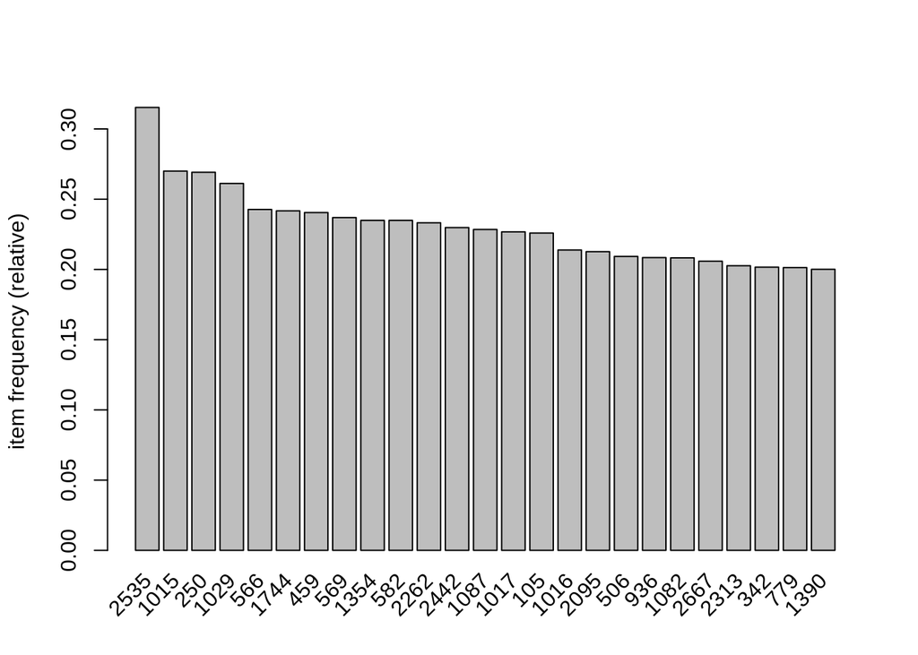

```r
itemFrequencyPlot(customersProducts, topN = 25)
```

```r
summary(customersProducts)
```

```
## transactions as itemMatrix in sparse format with
##  5892 rows (elements/itemsets/transactions) and
##  10539 columns (items) and a density of 0.008768598
##
## most frequent items:
##    2535    1015     250    1029     566 (Other)
##    1858    1591    1586    1539    1430  536489
##
## element (itemset/transaction) length distribution:
## sizes
##    6    7    8    9   10   11   12   13   14   15   16   17   18   19   20
##    1    5    7   20   37   55   77   78  120  113  121  104  122  118   94
##   21   22   23   24   25   26   27   28   29   30   31   32   33   34   35
##   79   93   85   77   66   74   84   72   72   74   77   58   50   58   39
##   36   37   38   39   40   41   42   43   44   45   46   47   48   49   50
```

[output cut: 68 more lines]

A continuación vamos a obtener reglas de asociación utilizando el algoritmo apriori. Para esto necesitamos calcular los valores para “soporte” y “confianza”.

Confianza: La confianza representa las ocasiones en la que la regla es correcta. El valor por defecto es 0,8. Vamos a empezar por este valor e iremos bajándolo para ver otras reglas.

```r
rules = apriori(data = customersProducts,
               parameter = list(support = 0.012, confidence = 0.71, maxtime = 0))
```

```
## Apriori
##
## Parameter specification:
##  confidence minval smax arem  aval originalSupport maxtime support minlen
##        0.71    0.1    1 none FALSE            TRUE       0   0.012      1
##  maxlen target   ext
##      10  rules FALSE
##
## Algorithmic control:
##  filter tree heap memopt load sort verbose
##     0.1 TRUE TRUE  FALSE TRUE    2    TRUE
##
## Absolute minimum support count: 70
##
## set item appearances ...[0 item(s)] done [0.00s].
## set transactions ...[10539 item(s), 5892 transaction(s)] done [0.07s].
## sorting and recoding items ... [1803 item(s)] done [0.02s].
## creating transaction tree ... done [0.00s].
## checking subsets of size 1 2 3 4 5 done [4.78s].
## writing ... [9 rule(s)] done [0.09s].
## creating S4 object  ... done [0.03s].
```

Hemos tenido que bajar la confianza hasta 0,71 y con estos parámetros hemos conseguido 9 reglas. Inspeccionemos las reglas.

```r
inspect(sort(rules, by = 'lift'))
```

```
##     lhs                rhs    support    confidence lift     count
## [1] {1458,1989}     => {1033} 0.01205024 0.7395833  3.915207 71
## [2] {3156,520,568}  => {1057} 0.01205024 0.7319588  3.711447 71
## [3] {1354,2092,566} => {2590} 0.01306857 0.7129630  3.681663 77
## [4] {1033,1185,520} => {1057} 0.01255940 0.7115385  3.607904 74
## [5] {2262,3408,681} => {1354} 0.01221996 0.7272727  3.096164 72
## [6] {1333,2154}     => {1354} 0.01205024 0.7100000  3.022630 71
## [7] {2590,718,914}  => {566}  0.01205024 0.7100000  2.925399 71
## [8] {1728,566,568}  => {1015} 0.01221996 0.7272727  2.693332 72
## [9] {1016,2663}     => {1015} 0.01289885 0.7102804  2.630403 76
```

- Lhs: El grupo de objetos sacado del set de datos.
- Rhs: El objeto predicho por el algoritmo.
- Support: El soporte de la regla.
- Confidence: La confianza de la regla.
- Lift: El valor de independencia/dependencia de la regla.
- Count: El número de veces que la regla aparece en nuestro set de datos.

Visualicemos estas reglas como grafo.

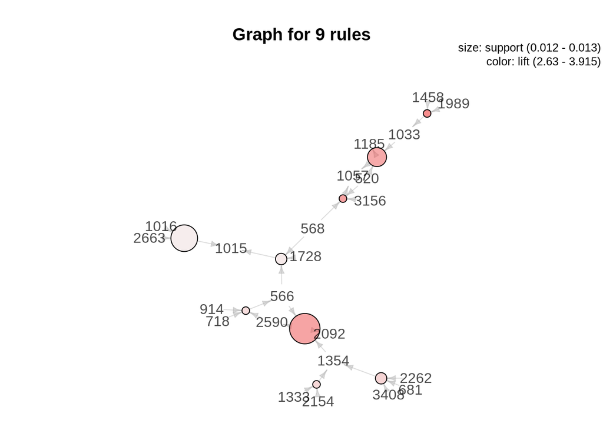

```r
plot(rules, method = 'graph')
```

Probemos bajando más la confianza, hasta 0,65.

```r
rules = apriori(data = customersProducts,
               parameter = list(support = 0.012, confidence = 0.65, maxtime = 0))
```

```
## Apriori
##
## Parameter specification:
##  confidence minval smax arem  aval originalSupport maxtime support minlen
##        0.65    0.1    1 none FALSE            TRUE       0   0.012      1
##  maxlen target   ext
##      10  rules FALSE
##
## Algorithmic control:
##  filter tree heap memopt load sort verbose
##     0.1 TRUE TRUE  FALSE TRUE    2    TRUE
##
## Absolute minimum support count: 70
##
## set item appearances ...[0 item(s)] done [0.00s].
## set transactions ...[10539 item(s), 5892 transaction(s)] done [0.08s].
## sorting and recoding items ... [1803 item(s)] done [0.02s].
## creating transaction tree ... done [0.00s].
## checking subsets of size 1 2 3 4 5 done [4.71s].
## writing ... [333 rule(s)] done [0.09s].
## creating S4 object  ... done [0.04s].
```

En este caso encontramos 333 reglas. Vamos a visualizarlas parcialmente.

```r
inspect(head(sort(rules, by = 'lift')))
```

```
##     lhs                 rhs    support    confidence lift     count
## [1] {2224,520,837}   => {3102} 0.01221996 0.6728972  5.044161 72
## [2] {1421,919}       => {969}  0.01221996 0.7058824  4.662622 72
## [3] {1019,1033,1181} => {961}  0.01221996 0.6605505  4.300512 72
## [4] {1033,3319,961}  => {1019} 0.01205024 0.6960784  4.084954 71
## [5] {1057,3102,3156} => {520}  0.01238968 0.6517857  3.967274 73
## [6] {1033,2381,961}  => {1019} 0.01238968 0.6759259  3.966689 73
```

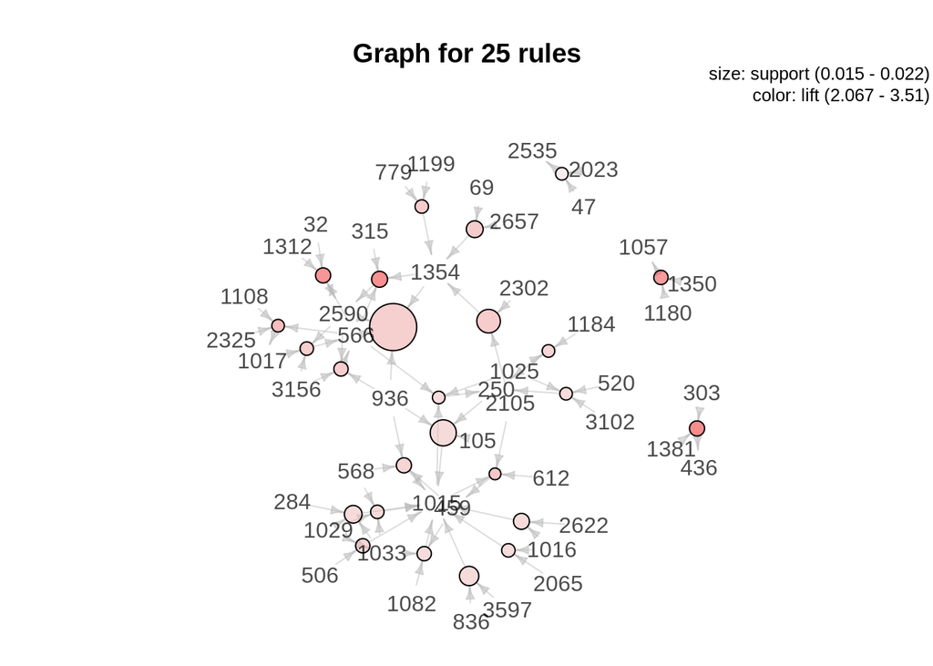

```r
plot(rules, method = 'graph', max = 25)
```

En este caso probaremos a visualizarlas agrupadas para verlas más facilmente.

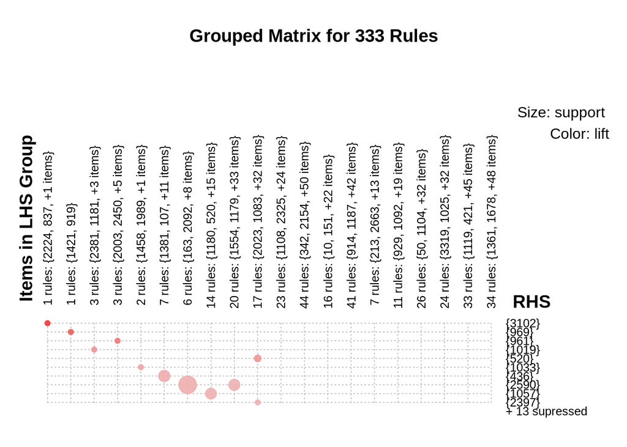

```r
plot(rules, method = 'grouped')
```

Con esto hemos encontrados reglas que determinan articulos comprados con una confianza mayor al 70%. También tenemos más reglas rebajando algo la confianza.